# R Notebook

4.4.1

A financier was interested in estimating the average number of trading days between the announcement of a merger and the effective date of merger. 38 consummated mergers from 1982 in the USA were randomly selected. The variable measured was:

mergerdays: the number of days between announcement and the effective date of the merger.

The dataset used for this analysis can be found in the s20x package.

|  | mergerdays |
| --- | --- |
| 1 | 74 |
| 2 | 45 |
| 3 | 55 |

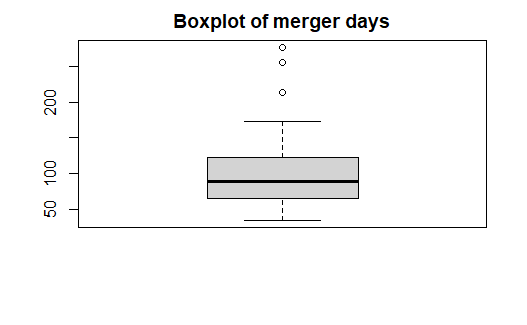

1. Comment briefly on the exploratory analysis of this dataset.

Ans: The median number of days stayed appears to be 89. The spread appears to be around 240 and the data appears to be right skewed.

```r
layout20x(1, 1)
summaryStats(mergers.df$mergerdays)
```

```
Minimum value:           35
Maximum value:           277
Mean value:              101.76
Median:                  89
Upper quartile:          121.25
Lower quartile:          67
Variance:                2848.46
Standard deviation:      53.37
Midspread (IQR):         54.25
Skewness:                1.68
Number of data values:   38
```

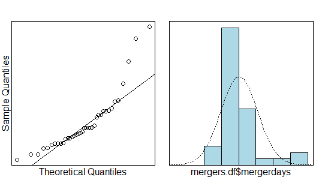

2. What can we conclude from the output of normcheck(mergers.df$mergerdays)?

Ans: The data points don’t lie on a line on the QQ plot. So, the normality of the data is not valid.

3. Suppose we did find a confidence interval for the mean number of days between the announcement and actual merger. Would that analysis be valid?

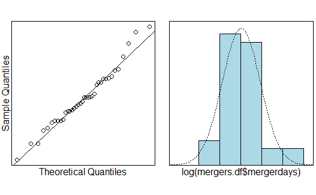

```r
normcheck(log(mergers.df$mergerdays))
```

4. Has a log transformation improved the situation with regards to modelling assumptions?

Ans: Yes, now the normality of the data seems to be valid as seen from the data points on the line on the QQ plot.

```r
t.test(log(mergers.df$mergerdays))
```

```
    One Sample t-test

data:  log(mergers.df$mergerdays)
t = 61.29, df = 37, p-value < 2.2e-16
alternative hypothesis: true mean is not equal to 0
95 percent confidence interval:
 4.366109 4.664656
sample estimates:
mean of x
 4.515383
```

```r
exp(t.test(log(mergers.df$mergerdays))$conf.int)
```

```
[1]  78.73665 106.12911
attr(,"conf.level")
[1] 0.95
```

5. What can we conclude from the p-value of the t-test?

6. Write a brief Executive Summary detailing the findings from this analysis.

Ans: We are interested in finding the number of days between the announcement of a merger and the effective date of the merger for companies from 1982, USA based on 38 mergers.

We had to transform these data in order to perform the analysis. As a consequence, our analysis estimates the median number of days between the two events.